# Lecture 3

Last time: Variables, types, defining functions

Today:

- a couple more things about variables and functions
- If-else, comparisons, booleans

**Exercise:** What will this code do?

```python
x = 1
y = 2
print(x,y)
y = x
x = y
print(x,y)
```

```
1 2
1 1
```

I actually wanted to swap x and y, how do I do it?

```python
x = 1
y = 2
print(x,y)
z = x
x = y
y = z
print(x,y)
```

```
1 2
2 1
```

We also talked about the difference between local and global variables. For example.

```python
def f(x):
    zzz = 1
    return x
```

```python
zzz
```

```
---------------------------------------------------------------------------
NameError                                 Traceback (most recent call last)
<ipython-input-4-33b02bc15ce9> in <module>()
----> 1 zzz

NameError: name 'zzz' is not defined
```

We get an error because zzz is a local variable (inside the function) not global variable.

Will there be an error?

```python
ggg = 1
def f(x):
    return x+ggg

print(f(0))
```

```
1
```

No. No problem. Global variables can be used inside the function.

Now, what will the following code produce?

```python
ggg = 1
def f(x):
    ggg = 2
    return x+ggg
f(0)
```

```
2
```

```python
# What about this?
print(ggg)
```

```
1
```

Aha! Something funny is happening here. In fact, when we said ggg=2 inside the function, that ggg was a *new* local variable, not the ggg from outside the function. This is a safety measure that prevents your functions from messing up the values of your global variables.

If you really want to change the value, you use the `global` keyword.

```python
ggg = 1
def f(x):
    global ggg
    ggg = 2
    return x+ggg
print(f(0))
print(ggg)
```

```
2
2
```

The `global` keyword tells python that the ggg inside the function is actually a global variable, and not a new local variable that would disappear after the function is completed.

## If-else

Let's import the library from the homework.

```python
# importing graphfunction() and drawfunction()
import libmath9 as math9
```

```python
def f(x):
    return x**2
```

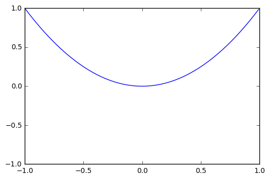

```python
math9.graphfunction(f)
```

Now we want to make a partial function, e.g. $$f(x) = \left\{ \begin{array}{ll} 0 & \mbox{if } x < 0 \\ x & \mbox{otherwise } \end{array} \right.$$

(by the way this function is called the RELU function)

We need to use the **if-else** syntax

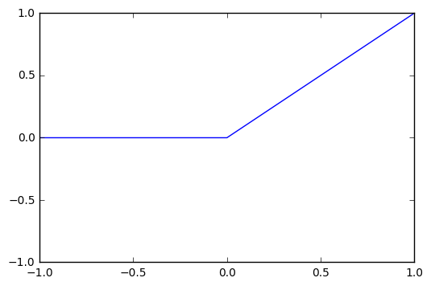

```python
def relu(x):
    if x > 0:
        return x
    else:
        return 0.0   # note: it gets confused if we put 0 instead of 0.0

math9.graphfunction(relu)
```

Actually, we could have written it like this:

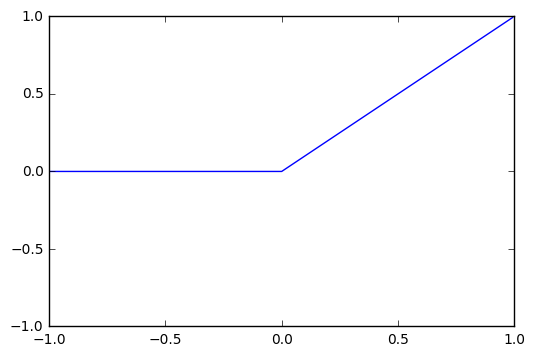

```python
def relu(x):
    if x > 0:
        return x
    return 0.0    # no need for else, because return will end the function anyway

math9.graphfunction(relu)
```

Like in the above example, you don't need to have an else every time there is an if.

```python
def safe_div(x,y):
    if y == 0:
        print("Noooo. You are dividing by zero bruuuuh!")
        return x/0.0000000000001
    return x/y

safe_div(1,0)
```

```
Noooo. You are dividing by zero bruuuuh!
```

```
10000000000000.0
```

#### Comparisons in python:

- `x < y`
- `x <= y`
- `x > y`
- `x >= y`
- `x == y`
- `x != y`

What is x < y anyway?

```python
0 < 1
```

```
True
```

```python
1 < 0
```

```
False
```

```python
type(1 != 1)
```

```
bool
```

```python
type(False)
```

```
bool
```

So there is a type called `bool`. It can have values True or False.

**Exercise** Let's make this one: $$f(x) = \left\{ \begin{array}{ll} 0.5 & \mbox{if } 0 \leq x \leq 0.5 \\ 0 & \mbox{otherwise } \end{array} \right.$$

```python
def f(x):
    if x >= 0:
        if x <= 0.5:
            return 0.5
    return 0.0
```

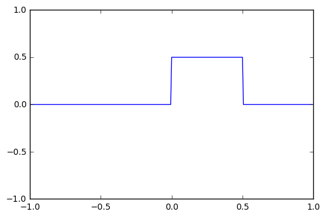

```python
math9.graphfunction(f)
```

Why not combine `x >= 0` and `x <= 0.5`. We need to and them:

```python
def f(x):
    if x >= 0 and x <= 0.5:
            return 0.5
    return 0.0
```

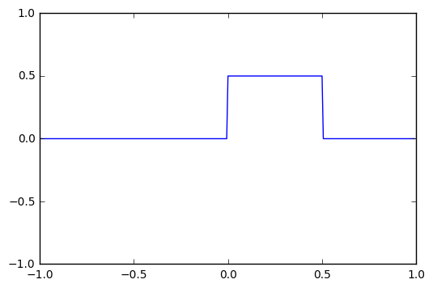

```python
math9.graphfunction(f)
```

### Boolean operations:

`and`, `or`, `not`

```python
True and True
```

```
True
```

```python
False and True
```

```
False
```

```python
not True
```

```
False
```

```python
True or False
```

```
True
```

**Weird example:** Life planner app

```python
checking = 400
savings = 400
debt  = 700
rich_relative = False

if checking + savings - debt < 200 and not rich_relative:
    print("No more cold pressed juice for you!")
elif checking + savings - debt > 500 or rich_relative:
    print("Ordering cold pressed juice and reserving VIP table at club...")
else:
    print("Do what's in your heart.")
```

```
No more cold pressed juice for you!
```

## Good exercises:

- Write a function `valid_day(year, month, day)` which tells you if a day exists or not.
- Write a function `is_last_digit_prime(n)` which will return True if the last digit of n is prime